# Case Study 1

Alex

2/9/2022

## Introduction

Cyclistic, a fictional bike-sharing company in Chicago wants to know in what ways do members and casual riders use Divvy bikes differently? Members being defined as users who have bought an annual subscription and casuals as those who buy single rides or day passes.

## 1. Importing and Wrangling the Dataset

The [data used](https://divvy-tripdata.s3.amazonaws.com/index.html) is historical data of Cyclistic Inc.. The data has been made publicly available by Motivate International Inc. under this [license.](https://ride.divvybikes.com/data-license-agreement)

```r
#set working directory with the csvs first
#example:
#setwd("C:/Users/Alex/Documents/Data Analysis/Case Studies/CS1 Data")
#create a single dataframe by combining the csvs
# all_trips2021 <- list.files(pattern = "*.csv") %>%
#   lapply(., read.csv, header = TRUE) %>%
#   do.call(rbind, .)

#alternatively use vroom for fast creation of a tibble with same purpose as above
all_trips2021 <- vroom(list.files(pattern = "*.csv"))
glimpse(all_trips2021)
```

```
## Rows: 5,595,063
## Columns: 13
## $ ride_id            <chr> "E19E6F1B8D4C42ED", "DC88F20C2C55F27F", "EC45C94683~
## $ rideable_type      <chr> "electric_bike", "electric_bike", "electric_bike", ~
## $ started_at         <dttm> 2021-01-23 16:14:19, 2021-01-27 18:43:08, 2021-01-~
## $ ended_at           <dttm> 2021-01-23 16:24:44, 2021-01-27 18:47:12, 2021-01-~
## $ start_station_name <chr> "California Ave & Cortez St", "California Ave & Cor~
## $ start_station_id   <chr> "17660", "17660", "17660", "17660", "17660", "17660~
## $ end_station_name   <chr> NA, NA, NA, NA, NA, NA, NA, NA, NA, "Wood St & Augu~
## $ end_station_id     <chr> NA, NA, NA, NA, NA, NA, NA, NA, NA, "657", "13258",~
## $ start_lat          <dbl> 41.90034, 41.90033, 41.90031, 41.90040, 41.90033, 4~
## $ start_lng          <dbl> -87.69674, -87.69671, -87.69664, -87.69666, -87.696~
## $ end_lat            <dbl> 41.89000, 41.90000, 41.90000, 41.92000, 41.90000, 4~
## $ end_lng            <dbl> -87.72000, -87.69000, -87.70000, -87.69000, -87.700~
## $ member_casual      <chr> "member", "member", "member", "member", "casual", "~
```

The data types for every column seem good, so we will go on to the next step, which is to remove a few columns regarding customer privacy.

```r
#Remove unnecessary columns (geospatial data columns)
all_trips2021 <- select(all_trips2021, -c(start_lat, start_lng, end_lat, end_lng))
```

Now we can rename a few columns for more clarity and consistency. Afterwards we’ll be ready for data cleaning.

```r
all_trips2021 <- rename(all_trips2021
                        ,trip_id = ride_id
                        ,bikeid = rideable_type
                        ,start_time = started_at
                        ,end_time = ended_at
                        ,from_station_name = start_station_name
                        ,from_station_id = start_station_id
                        ,to_station_name = end_station_name
                        ,to_station_id = end_station_id
                        ,usertype = member_casual)
```

## 2. Data Cleaning

Now that the data has been shaped into a cleaner format, it is time to clean the data to prepare for analysis. We will start by getting a quick overview of the data frame with the glimpse() function.

```r
glimpse(all_trips2021)
```

```
## Rows: 5,595,063
## Columns: 9
## $ trip_id           <chr> "E19E6F1B8D4C42ED", "DC88F20C2C55F27F", "EC45C94683F~
## $ bikeid            <chr> "electric_bike", "electric_bike", "electric_bike", "~
## $ start_time        <dttm> 2021-01-23 16:14:19, 2021-01-27 18:43:08, 2021-01-2~
## $ end_time          <dttm> 2021-01-23 16:24:44, 2021-01-27 18:47:12, 2021-01-2~
## $ from_station_name <chr> "California Ave & Cortez St", "California Ave & Cort~
## $ from_station_id   <chr> "17660", "17660", "17660", "17660", "17660", "17660"~
## $ to_station_name   <chr> NA, NA, NA, NA, NA, NA, NA, NA, NA, "Wood St & Augus~
## $ to_station_id     <chr> NA, NA, NA, NA, NA, NA, NA, NA, NA, "657", "13258", ~
## $ usertype          <chr> "member", "member", "member", "member", "casual", "c~
```

Some quick observations: There are some null values in the from/to station_name and station_id columns. The usertype column also seems to only have two values; “member” and “casual”. Let’s confirm this while also counting how many occurrences of each there are.

```r
table(all_trips2021$usertype)
```

```
##
##  casual  member
## 2529005 3066058
```

With that out of the way, let’s proceed with cleanup and prep. One statistic that would be useful is a trip duration, so we will create a column. We will also make sure nothing weird is happening by checking for negative trip durations and removing any. Because we are transforming the data, we will create a new data frame.

```r
all_trips2021v2 <-  mutate(all_trips2021, tripduration = end_time - start_time) %>%
  filter(tripduration > 0)
#set "tripduration" to a numeric class so we can run calculations
all_trips2021v2$tripduration <- as.numeric(all_trips2021v2$tripduration)
```

We also want to add columns to aggregate data for each month, day (and weekdays), or year.

```r
all_trips2021v2$date <- as.Date(all_trips2021v2$start_time) #The default format is yyyy-mm-dd
all_trips2021v2$month <- format(as.Date(all_trips2021v2$date), "%m")
all_trips2021v2$day <- format(as.Date(all_trips2021v2$date), "%d")
all_trips2021v2$year <- format(as.Date(all_trips2021v2$date), "%Y")
all_trips2021v2$day_of_week <- format(as.Date(all_trips2021v2$date), "%A")
```

## 3. Descriptive Analysis

We want to answer the question: “In what ways do members and casuals use Divvy bikes?” A summary() function shows basic summary statistics, but it is quickly noticed that most variables don’t provide much info.

```r
summary(all_trips2021v2)
```

```
##    trip_id             bikeid            start_time
##  Length:5594410     Length:5594410     Min.   :2021-01-01 00:02:05
##  Class :character   Class :character   1st Qu.:2021-06-06 23:48:04
##  Mode  :character   Mode  :character   Median :2021-08-01 01:47:45
##                                        Mean   :2021-07-29 07:38:35
##                                        3rd Qu.:2021-09-24 16:34:56
##                                        Max.   :2021-12-31 23:59:48
##     end_time                   from_station_name  from_station_id
##  Min.   :2021-01-01 00:08:39   Length:5594410     Length:5594410
##  1st Qu.:2021-06-07 00:39:47   Class :character   Class :character
##  Median :2021-08-01 02:16:53   Mode  :character   Mode  :character
##  Mean   :2021-07-29 08:00:31
##  3rd Qu.:2021-09-24 16:52:38
##  Max.   :2022-01-03 17:32:18
##  to_station_name    to_station_id        usertype          tripduration
##  Length:5594410     Length:5594410     Length:5594410     Min.   :      1
##  Class :character   Class :character   Class :character   1st Qu.:    405
##  Mode  :character   Mode  :character   Mode  :character   Median :    720
##                                                           Mean   :   1316
##                                                           3rd Qu.:   1307
##                                                           Max.   :3356649
##       date               month               day                year
##  Min.   :2021-01-01   Length:5594410     Length:5594410     Length:5594410
##  1st Qu.:2021-06-06   Class :character   Class :character   Class :character
##  Median :2021-08-01   Mode  :character   Mode  :character   Mode  :character
##  Mean   :2021-07-28
##  3rd Qu.:2021-09-24
##  Max.   :2021-12-31
##  day_of_week
##  Length:5594410
##  Class :character
##  Mode  :character
##
##
##
```

The only variable that is informative is tripduration so we will focus on that.

```r
summary(all_trips2021v2$tripduration)
```

```
##    Min. 1st Qu.  Median    Mean 3rd Qu.    Max.
##       1     405     720    1316    1307 3356649
```

On average, users use Divvy bikes for 1316 seconds or approximately 22 minutes at a time. The median is 12 minutes, indicating some skew. Skew is not the main focus of this task, but it is nevertheless an interesting statistic. We will move on to analyzing further into the differences between members and casual users.

```r
aggregate(all_trips2021v2$tripduration/60 ~ all_trips2021v2$usertype, FUN = mean)
```

```
##   all_trips2021v2$usertype all_trips2021v2$tripduration/60
## 1                   casual                        32.00578
## 2                   member                        13.63455
```

```r
aggregate(all_trips2021v2$tripduration/60 ~ all_trips2021v2$usertype, FUN = median)
```

```
##   all_trips2021v2$usertype all_trips2021v2$tripduration/60
## 1                   casual                        15.98333
## 2                   member                         9.60000
```

```r
aggregate(all_trips2021v2$tripduration/60 ~ all_trips2021v2$usertype, FUN = max)
```

```
##   all_trips2021v2$usertype all_trips2021v2$tripduration/60
## 1                   casual                       55944.150
## 2                   member                        1559.933
```

```r
aggregate(all_trips2021v2$tripduration ~ all_trips2021v2$usertype, FUN = min)
```

```
##   all_trips2021v2$usertype all_trips2021v2$tripduration
## 1                   casual                            1
## 2                   member                            1
```

We can see that casual users tend to ride for longer than members. Casual users average 32 minutes per trip and members average 13.6 minutes per trip; more than double. One explanation could be that members are city residents who use the bikes to commute to work or school and back. Meanwhile, casuals might be tourists exploring the city, thus using the bikes for longer.

We can delve deeper by analyzing bike usage by day of the week. We will first reorder the days of the week then analyze.

```r
all_trips2021v2$day_of_week <- ordered(all_trips2021v2$day_of_week,levels=c("Sunday",  "Monday", "Tuesday", "Wednesday", "Thursday", "Friday", "Saturday"))

aggregate(all_trips2021v2$tripduration/60 ~ all_trips2021v2$usertype + all_trips2021v2$day_of_week, FUN = mean)
```

```
##    all_trips2021v2$usertype all_trips2021v2$day_of_week
## 1                    casual                      Sunday
## 2                    member                      Sunday
## 3                    casual                      Monday
## 4                    member                      Monday
## 5                    casual                     Tuesday
## 6                    member                     Tuesday
## 7                    casual                   Wednesday
## 8                    member                   Wednesday
## 9                    casual                    Thursday
## 10                   member                    Thursday
## 11                   casual                      Friday
## 12                   member                      Friday
## 13                   casual                    Saturday
## 14                   member                    Saturday
##    all_trips2021v2$tripduration/60
## 1                         37.57096
## 2                         15.65923
## 3                         31.87912
## 4                         13.24826
## 5                         27.97549
## 6                         12.78908
## 7                         27.66107
## 8                         12.82021
## 9                         27.70578
## 10                        12.77703
## 11                        30.35177
## 12                        13.32608
## 13                        34.70997
## 14                        15.26552
```

Next we will combine the previous analyses to group the rider types, days of the week, number of rides and the average duration per ride. To make it more accessible for multiple analyses we will also assign it to a new object labeled trips_summaries. (not necessary but looks neater)

```r
trips_summaries <- all_trips2021v2 %>%
  mutate(weekday = wday(start_time, label = TRUE)) %>%  #creates weekday field using wday()
  group_by(usertype, weekday) %>%  #groups by usertype and weekday
  summarise(number_of_rides = n()                           #calculates the number of rides and average duration
            ,average_duration = mean(tripduration)/60) %>% # calculates the average duration
  arrange(usertype, weekday)
```

## 4. Visualizing the Data

Everything done so far has been done with some programming and numbers. It can be hard to fully grasp the outputs and their meanings, so next up we will make visuals so that the information can be easily understood within a few seconds.

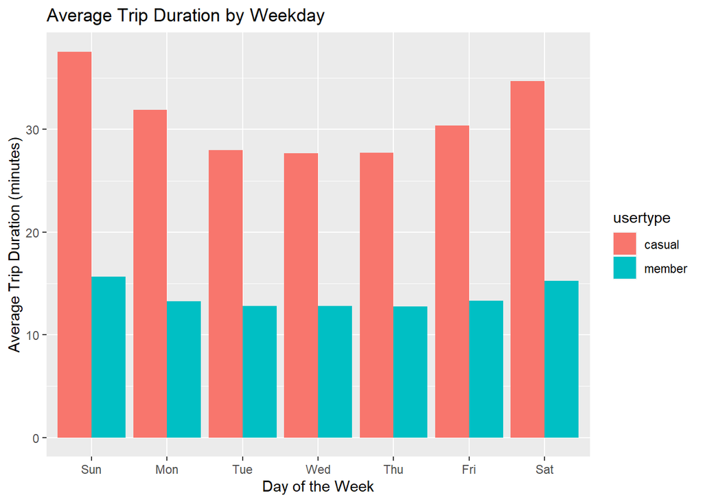

```r
trips_summaries %>%
  ggplot(aes(x = weekday, y = average_duration, fill = usertype)) +
  geom_col(position = 'dodge') +
  labs(title = "Average Trip Duration by Weekday") +
  xlab("Day of the Week") +
  ylab("Average Trip Duration (minutes)")
```

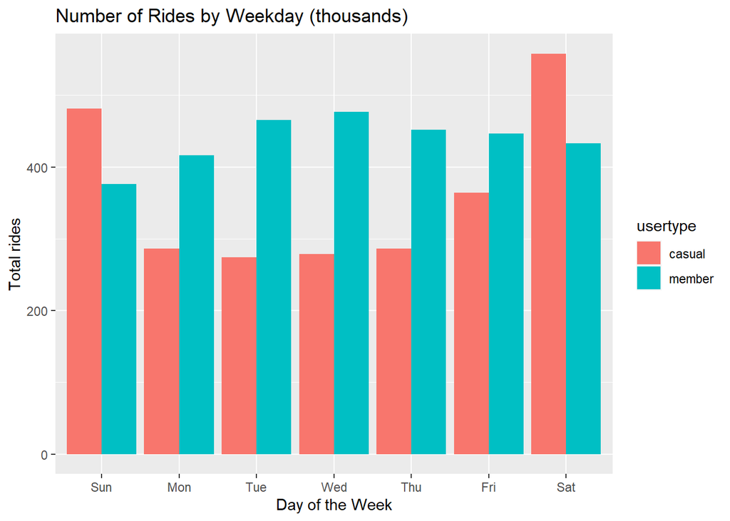

```r
options(scipen = 999) #no scientific notation for # of rides label
trips_summaries %>%
  ggplot(aes(x = weekday, y = number_of_rides/1000, fill = usertype)) +
  geom_col(position = "dodge") +
  labs(title = "Number of Rides by Weekday (thousands)") +
  xlab("Day of the Week") +
  ylab("Total rides")
```

If we only looked at the first graphic, we might incorrectly assume that casual riders make up most of the customer base, but we know from a previous count that there are more members’ rides than casuals’ rides. The second graphic highlights this; we see that during the weekdays (Monday through Friday), there are more rides by members than casuals. Starting on Friday, we notice that there is a significant increase in the number of casual rides, surpassing member usage on Saturdays and Sundays.

These observations strengthen our hypothesis that members are more likely to use these bikes for commuting meanwhile casuals are more likely to use the bikes for leisure activities.

## 5. Summary and Recommendations

Some business suggestions to make use of this information:

1. Offer a weekend only annual pass. Have a lower cost than annual pass to incentivize overall more subscriptions for the more casual residents of Chicago who do not use bikes to commute.
2. Create guided tour suggestions for people who want to explore the city.